# Titanic Passenger Data Analysis

## Project Objective

This Project will explore the demographics and passenger information provided for 891 of the 2224 passengers and crew that were on board the Titanic.

Data was provided as a CSV by [Kaggle](https://www.kaggle.com/c/titanic/data)

## Project Questions

1. What factors made people more likely to survive?

```python
#git remote add origin https://github.com/AdkinsWx/Udacity_Titanic.git
#git push -u origin master

import numpy as np
import pandas as pd
import matplotlib.pyplot as plt
import csv
import seaborn as sns
from IPython.display import display
%matplotlib inline
```

## Data Wrangling

First I wanted to display the data in table to get a visual of the data and to try and find any future issues.

```python
#Views a piece of the data table to verify if there are any pieces of the data that needs to be cleaned
sample_data = pd.read_csv('titanic-data.csv')
display(sample_data.head(20))
```

|  | PassengerId | Survived | Pclass | Name | Sex | Age | SibSp | Parch | Ticket | Fare | Cabin | Embarked |
| --- | --- | --- | --- | --- | --- | --- | --- | --- | --- | --- | --- | --- |
| 0 | 1 | 0 | 3 | Braund, Mr. Owen Harris | male | 22.0 | 1 | 0 | A/5 21171 | 7.2500 | NaN | S |
| 1 | 2 | 1 | 1 | Cumings, Mrs. John Bradley (Florence Briggs Th... | female | 38.0 | 1 | 0 | PC 17599 | 71.2833 | C85 | C |
| 2 | 3 | 1 | 3 | Heikkinen, Miss. Laina | female | 26.0 | 0 | 0 | STON/O2. 3101282 | 7.9250 | NaN | S |
| 3 | 4 | 1 | 1 | Futrelle, Mrs. Jacques Heath (Lily May Peel) | female | 35.0 | 1 | 0 | 113803 | 53.1000 | C123 | S |
| 4 | 5 | 0 | 3 | Allen, Mr. William Henry | male | 35.0 | 0 | 0 | 373450 | 8.0500 | NaN | S |
| 5 | 6 | 0 | 3 | Moran, Mr. James | male | NaN | 0 | 0 | 330877 | 8.4583 | NaN | Q |
| 6 | 7 | 0 | 1 | McCarthy, Mr. Timothy J | male | 54.0 | 0 | 0 | 17463 | 51.8625 | E46 | S |
| 7 | 8 | 0 | 3 | Palsson, Master. Gosta Leonard | male | 2.0 | 3 | 1 | 349909 | 21.0750 | NaN | S |
| 8 | 9 | 1 | 3 | Johnson, Mrs. Oscar W (Elisabeth Vilhelmina Berg) | female | 27.0 | 0 | 2 | 347742 | 11.1333 | NaN | S |
| 9 | 10 | 1 | 2 | Nasser, Mrs. Nicholas (Adele Achem) | female | 14.0 | 1 | 0 | 237736 | 30.0708 | NaN | C |
| 10 | 11 | 1 | 3 | Sandstrom, Miss. Marguerite Rut | female | 4.0 | 1 | 1 | PP 9549 | 16.7000 | G6 | S |
| 11 | 12 | 1 | 1 | Bonnell, Miss. Elizabeth | female | 58.0 | 0 | 0 | 113783 | 26.5500 | C103 | S |
| 12 | 13 | 0 | 3 | Saundercock, Mr. William Henry | male | 20.0 | 0 | 0 | A/5. 2151 | 8.0500 | NaN | S |
| 13 | 14 | 0 | 3 | Andersson, Mr. Anders Johan | male | 39.0 | 1 | 5 | 347082 | 31.2750 | NaN | S |
| 14 | 15 | 0 | 3 | Vestrom, Miss. Hulda Amanda Adolfina | female | 14.0 | 0 | 0 | 350406 | 7.8542 | NaN | S |
| 15 | 16 | 1 | 2 | Hewlett, Mrs. (Mary D Kingcome) | female | 55.0 | 0 | 0 | 248706 | 16.0000 | NaN | S |
| 16 | 17 | 0 | 3 | Rice, Master. Eugene | male | 2.0 | 4 | 1 | 382652 | 29.1250 | NaN | Q |
| 17 | 18 | 1 | 2 | Williams, Mr. Charles Eugene | male | NaN | 0 | 0 | 244373 | 13.0000 | NaN | S |
| 18 | 19 | 0 | 3 | Vander Planke, Mrs. Julius (Emelia Maria Vande... | female | 31.0 | 1 | 0 | 345763 | 18.0000 | NaN | S |
| 19 | 20 | 1 | 3 | Masselmani, Mrs. Fatima | female | NaN | 0 | 0 | 2649 | 7.2250 | NaN | C |

### Possible Issues with the Data

After viewing the table below we can see that not all data points are accounted for. For instance on Line [5], Mr. James Moran's age and cabin number are missing (Other passengers even have multiple cabin numbers).

For this missing cabin data I replaced the NaN with a "unknown" string. This could help with labeling and stop those lines of data being dropped from certain functions.

The missing "Age" data can be addressed in a number of ways:

1. Replacing with 0. a. This would give rid of the NaN. However, when plotting the data it would artificially skew the data towards 0. This would lead to false interpretations.
2. Replace with the average age. b. Again this would get rid of the NaN in the data. However, this could skew the data towards the median value.
3. Drop NaN values from the data set. c. Dropping the NaN value rows would work for Age specific statistics but wouldn't be necessary for every factor.

In the end I chose option 3, droping NaN values from the data for certain statistics. This seemed most reasonable because I won't need the Age data for every aspect of the analysis and thus the NaN's wouldn't be an issue. Thus once I needed Age specific data I could drop the NaN rows and continue my analysis.

Below I prescribed some code to remedy the Cabin columns.

```python
#The following codes replaces NaN in the Cabin column with Unknown


sample_data['Cabin'].fillna('unknown', inplace = True)
display(sample_data.head(20))
```

|  | PassengerId | Survived | Pclass | Name | Sex | Age | SibSp | Parch | Ticket | Fare | Cabin | Embarked |
| --- | --- | --- | --- | --- | --- | --- | --- | --- | --- | --- | --- | --- |
| 0 | 1 | 0 | 3 | Braund, Mr. Owen Harris | male | 22.0 | 1 | 0 | A/5 21171 | 7.2500 | unknown | S |
| 1 | 2 | 1 | 1 | Cumings, Mrs. John Bradley (Florence Briggs Th... | female | 38.0 | 1 | 0 | PC 17599 | 71.2833 | C85 | C |
| 2 | 3 | 1 | 3 | Heikkinen, Miss. Laina | female | 26.0 | 0 | 0 | STON/O2. 3101282 | 7.9250 | unknown | S |
| 3 | 4 | 1 | 1 | Futrelle, Mrs. Jacques Heath (Lily May Peel) | female | 35.0 | 1 | 0 | 113803 | 53.1000 | C123 | S |
| 4 | 5 | 0 | 3 | Allen, Mr. William Henry | male | 35.0 | 0 | 0 | 373450 | 8.0500 | unknown | S |
| 5 | 6 | 0 | 3 | Moran, Mr. James | male | NaN | 0 | 0 | 330877 | 8.4583 | unknown | Q |
| 6 | 7 | 0 | 1 | McCarthy, Mr. Timothy J | male | 54.0 | 0 | 0 | 17463 | 51.8625 | E46 | S |
| 7 | 8 | 0 | 3 | Palsson, Master. Gosta Leonard | male | 2.0 | 3 | 1 | 349909 | 21.0750 | unknown | S |
| 8 | 9 | 1 | 3 | Johnson, Mrs. Oscar W (Elisabeth Vilhelmina Berg) | female | 27.0 | 0 | 2 | 347742 | 11.1333 | unknown | S |
| 9 | 10 | 1 | 2 | Nasser, Mrs. Nicholas (Adele Achem) | female | 14.0 | 1 | 0 | 237736 | 30.0708 | unknown | C |
| 10 | 11 | 1 | 3 | Sandstrom, Miss. Marguerite Rut | female | 4.0 | 1 | 1 | PP 9549 | 16.7000 | G6 | S |
| 11 | 12 | 1 | 1 | Bonnell, Miss. Elizabeth | female | 58.0 | 0 | 0 | 113783 | 26.5500 | C103 | S |
| 12 | 13 | 0 | 3 | Saundercock, Mr. William Henry | male | 20.0 | 0 | 0 | A/5. 2151 | 8.0500 | unknown | S |
| 13 | 14 | 0 | 3 | Andersson, Mr. Anders Johan | male | 39.0 | 1 | 5 | 347082 | 31.2750 | unknown | S |
| 14 | 15 | 0 | 3 | Vestrom, Miss. Hulda Amanda Adolfina | female | 14.0 | 0 | 0 | 350406 | 7.8542 | unknown | S |
| 15 | 16 | 1 | 2 | Hewlett, Mrs. (Mary D Kingcome) | female | 55.0 | 0 | 0 | 248706 | 16.0000 | unknown | S |
| 16 | 17 | 0 | 3 | Rice, Master. Eugene | male | 2.0 | 4 | 1 | 382652 | 29.1250 | unknown | Q |
| 17 | 18 | 1 | 2 | Williams, Mr. Charles Eugene | male | NaN | 0 | 0 | 244373 | 13.0000 | unknown | S |
| 18 | 19 | 0 | 3 | Vander Planke, Mrs. Julius (Emelia Maria Vande... | female | 31.0 | 1 | 0 | 345763 | 18.0000 | unknown | S |
| 19 | 20 | 1 | 3 | Masselmani, Mrs. Fatima | female | NaN | 0 | 0 | 2649 | 7.2250 | unknown | C |

The ".fillna" worked well and distributed the unknown value throught the column.

While observing the table I also wanted to know what data types are in each column. This could possible help me avoid any issues when trying to manipulate the data.

```python
#The following checks the data type of a desired column
from pandas.api.types import is_numeric_dtype
from pandas.api.types import is_string_dtype
from pandas.api.types import is_bool

sample_data.dtypes
```

```
PassengerId      int64
Survived         int64
Pclass           int64
Name            object
Sex             object
Age            float64
SibSp            int64
Parch            int64
Ticket          object
Fare           float64
Cabin           object
Embarked        object
dtype: object
```

The table above shows that we have several different data types (int, float, object/string). One positive note is that each column is a expected data type. Ages are floats, Pclass' are ints, and Tickets are objects/strings.

Above I replaced the missing cabin values with "unknown". We can also see that there are missing numbers in the Age column. Later on in the anlysis I dropped the those rows from the table while trying to find Age specific statistics.

## Answering the Question (Exploring the Data)

### 1. What factors made people more likely to survive?

First lets start with any gender specific factors. I started by plotting the sample population's make-up by gender. To help compare a survivor rate I plotted the survivor's population make-p by gender as well. This will give us a side-by-side visual comparison.

Many stories from the Titanic state a policy of "Women and children first". Meaning that women and children had priority when boarding life boats. With this in mind we could expect to a higher female survivor rate than their male counterparts.

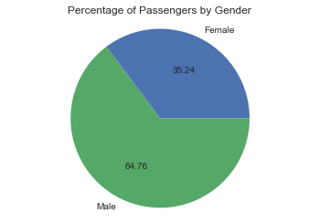

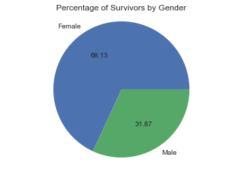

```python
survived_df = (sample_data.loc[sample_data['Survived'] == 1])

sample_gender = sample_data.groupby('Sex').size()
sample_gender.plot(kind='pie', autopct='%.2f', labels=('Female', 'Male'))
plt.title('Percentage of Passengers by Gender')
plt.axis('equal')
plt.ylabel('')
plt.show()


survived_gender = survived_df.groupby('Sex').size()
survived_gender.plot(kind='pie', autopct='%.2f', labels=('Female', 'Male'))

plt.title('Percentage of Survivors by Gender')
plt.axis('equal')
plt.ylabel('')
plt.show()
```

After plotting the two graphs we see that males were a larger part of the sample population at 64.76%, while females only makeup 35.24%. However, when it comes to surviving the disaster females have a significantly higher survival rate making up 68.13% of the surviving population.

This may not confirm the "Women and chldren first" policy but it ceratinly shows that females may have had an advantage in surviving the Titanic disaster.

One thing to ponder would be, "Would a 3rd class female have a better survival rate than a first class male?" To answer this I plotted the survival rates by class for each gender. Because of the cabin layouts, first class passengers did have more immediate access to life boats so we may see a some subset of males with a greater survival rate.

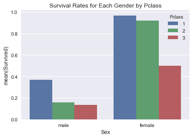

```python
male_df = (sample_data.loc[sample_data['Sex'] == 'male'])
male_survived = male_df.groupby('Survived')

sns.barplot(x="Sex", y="Survived", hue="Pclass", data=sample_data, ci=None)
plt.title("Survival Rates for Each Gender by Pclass")
```

Now that we have the survival rates for each gender broken down by Pclass we can notice a few things. First, a 3rd class female still has a higher survival rate than a 1st class male. Second, 3rd class females had a significantly lower than their female counterparts in 1st and 2nd class.

For males classes are just as significant. 1st class males show a larger spread in survival rate over the 2nd and 3rd class males. However, 2nd and 3rd class male survival rates are very similar to eachother.

#### Exploring Gender Factors

##### (Male Only Data)

Now let I wanted to explore male only age data using a histogram. This will hopefully give insight to which age groups had the highest survival rates.

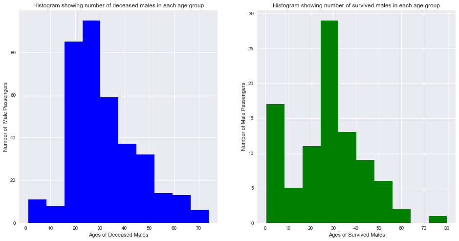

```python
fig, axs = plt.subplots(1, 2, figsize=(16,8))


color=['b','g']
for ind, grp in male_survived:
    grp['Age'].plot(kind='hist', color=color[ind], ax = axs[ind])
axs[0].set_xlabel('Ages of Deceased Males')
axs[0].set_ylabel('Number of  Male Passengers')
axs[0].set_title('Histogram showing number of deceased males in each age group')

axs[1].set_xlabel('Ages of Survived Males')
axs[1].set_ylabel('Number of Male Passengers')
axs[1].set_title('Histogram showing number of survived males in each age group')
```

Here we can see the male only passengers and their age groupings. We can see that most of the surviving males were in their late 20's to 30's or younger than 10 years old. It also appears that the most seniored males in our sample population survived.

##### (Female Only Data)

Next we will replicate the male histogram for the female population and see if there are any significant changes in the distribution.

[figure not shown]

```python
female_df = (sample_data.loc[sample_data['Sex'] == 'female'])

fig, axs = plt.subplots(1, 2, figsize=(16,8))

female_survived = female_df.groupby('Survived')
color=['b','g']
for ind, grp in female_survived:
    grp['Age'].plot(kind='hist', color=color[ind], ax = axs[ind])
axs[0].set_xlabel('Ages of Deceased Females')
axs[0].set_ylabel('Number of  Female Passengers')
axs[0].set_title('Histogram showing number of deceased females in each age group')

axs[1].set_xlabel('Ages of Survived Females')
axs[1].set_ylabel('Number of Female Passengers')
axs[1].set_title('Histogram showing number of deceased females in each age group')
```

Again we have the same two histograms as we had for the males. And the overall shapes are fairly similar. First the deceased female ages are skewed towards the younger ages. This could be because of the ages of the sample population were mostly younger females.

While the survived female histogram is a bit different than the males. The female male histogram isn't quite bimodal and qualifies to be more of a normal distribution.

#### Exploring Pclass Factors

Next I wanted to expand the Pclass factors to the general population. We already saw the significance it had in our gender specific analysis but I wanted to see want impiclations it had for the larger population.

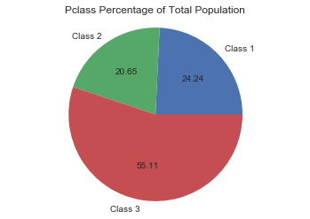

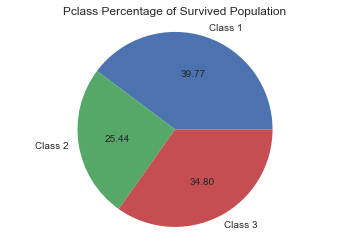

```python
# Below displays the total number of passengers
pclass_total_labels = ('Class 1', 'Class 2', 'Class 3')
pclass_total = sample_data.groupby('Pclass').size()
pclass_total.plot(kind='pie', autopct='%.2f', labels=pclass_total_labels)

plt.title('Pclass Percentage of Total Population')
plt.axis('equal')
plt.ylabel('')
plt.show()

# Below displays the number of survivors in each class


pclass_survived_labels = ('Class 1', 'Class 2', 'Class 3')

pclass_survived = survived_df.groupby('Pclass').size()
pclass_survived.plot(kind='pie', autopct='%.2f', labels=pclass_survived_labels)

plt.title('Pclass Percentage of Survived Population')
plt.axis('equal')
plt.ylabel('')
plt.show()
```

Here I started by plotting two pie graphs.

The first shows the percentage of total passengers in each Pclass. Here we can see that Class 3 passengers made the majority of the population followed by Class 1 and Class 2 respectively.

The second pie graph shows the percentage of survived passengers in each Pclass. Here we see that most of the survivors were Class 1 passengers.

By comparing the two graphs we can infer that Class 1 passengers had the highest survival rate and Class 3 had the worst survival rate. But I will make a bar graph to confirm this assumption.

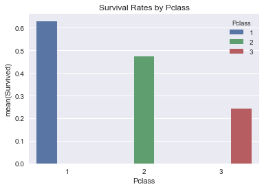

```python
sns.barplot(x="Pclass", y="Survived", hue="Pclass", data=sample_data, ci=None)
plt.title("Survival Rates by Pclass")
```

To confirm the assumptions made by comparing the pie graphs above I have calculated and plotted the survival rates in a bar graph. The chart confirms that Class 1 passengers and the highest survival rate and Class 3 survivors had the lowest survival rate.

This could be due to the layout of the ship where Class 1 passenger rooms were at the top of the ship with easy access to life boats. While the Class 3 passengers were below deck putting these passengers at a disadvantage.

#### Exploring Age Factors

In this section the unrecorded ages became an issue when getting accurate statistics and charts. I elected to create a new data frame and removed any passenger with NaN in the age column. This was accomplished by using:

titanic_dropNaN = sample_data[~np.isnan(sample_data['Age'])]

First I started by creating a baseline in finding the distribution of ages for the sample population.

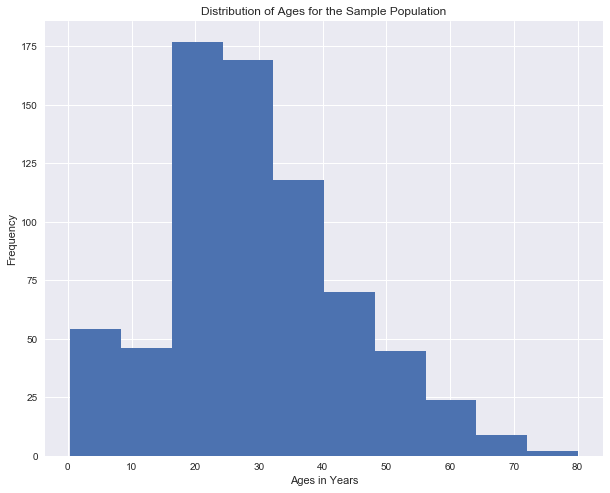

```python
titanic_dropNaN = sample_data[~np.isnan(sample_data['Age'])]


titanic_dropNaN['Age'].plot(kind='hist',figsize=(10,8), title = "Distribution of Ages for the Sample Population")
plt.xlabel('Ages in Years')
```

Next I split the population into two histograms. First showing deceased passengers and the second showing those that survived. We will see if we get a similar disribution to our total sample population.

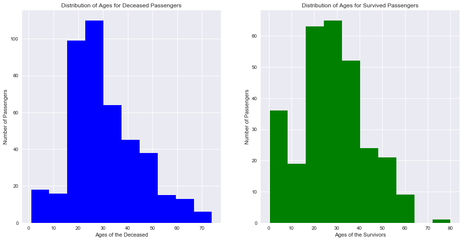

```python
fig, axs = plt.subplots(1, 2, figsize=(16,8))

age_survived = titanic_dropNaN.groupby('Survived')
color=['b','g']
for ind, grp in age_survived:
    grp['Age'].plot(kind='hist', color=color[ind], ax = axs[ind])
axs[0].set_xlabel('Ages of the Deceased')
axs[0].set_ylabel('Number of Passengers')
axs[0].set_title('Distribution of Ages for Deceased Passengers')

axs[1].set_xlabel('Ages of the Survivors')
axs[1].set_ylabel('Number of Passengers')
axs[1].set_title('Distribution of Ages for Survived Passengers')
```

The overall shape reflects the same as the total population.

Finally I broke down the data into age groups and labeled them. This helps gain a better view of each age group and help us determine which age group had the greatest survival rate. The labels are based on typical age groupings we see in everyday life. Note that some groupings are larger than others.

```
Grouping Criteria:
Children: 0-12 years old
Teenager: 13-19 years old
Adults: 20-59 years old
Seniors: 60+ years old
```

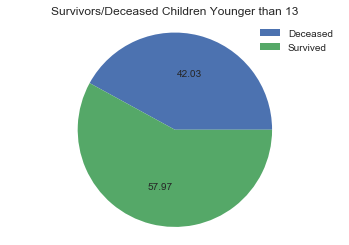

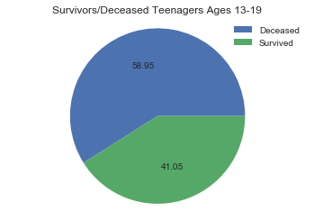

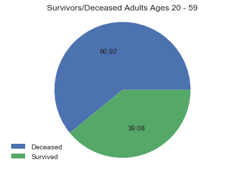

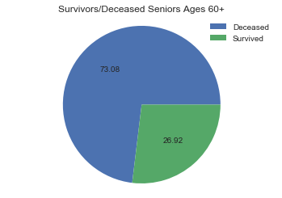

```python
children = titanic_dropNaN[titanic_dropNaN.Age <= 12].copy()
teenagers = titanic_dropNaN[(titanic_dropNaN.Age < 20)&(titanic_dropNaN.Age > 12)].copy()
adults = titanic_dropNaN[(titanic_dropNaN.Age < 59)& (titanic_dropNaN.Age >= 20)].copy()
seniors = titanic_dropNaN[(titanic_dropNaN.Age >= 60)]

group_names = ['Deceased','Survived']

survivor_children = children.groupby('Survived').size()
survivor_children.plot(kind='pie', autopct='%.2f', labels=None)

plt.title('Survivors/Deceased Children Younger than 13')
plt.axis('equal')
plt.ylabel('')
plt.legend(labels=group_names, loc="best")
plt.show()

survivor_teens = teenagers.groupby('Survived').size()
survivor_teens.plot(kind='pie', autopct='%.2f', labels=None)

plt.title('Survivors/Deceased Teenagers Ages 13-19')
plt.axis('equal')
plt.ylabel('')
plt.legend(labels=group_names, loc="best")
plt.show()

survivor_adults = adults.groupby('Survived').size()
survivor_adults.plot(kind='pie', autopct='%.2f', labels=None)

plt.title('Survivors/Deceased Adults Ages 20 - 59')
plt.axis('equal')
plt.ylabel('')
plt.legend(labels=group_names, loc="best")
plt.show()

survivor_seniors = seniors.groupby('Survived').size()
survivor_seniors.plot(kind='pie', autopct='%.2f', labels=None)

plt.title('Survivors/Deceased Seniors Ages 60+')
plt.axis('equal')
plt.ylabel('')
plt.legend(labels=group_names, loc="best")
plt.show()
```

Using the graphs we can again see that children ages 0-12 had the highest survival rate out of all the survivors. This could again infer the theory of "Women and children first" for those who had priority to life boats. Note that our oldest grouping, seniors aged 60+ years, had the lowest survival rate which further strengthens the "Women and children first" priority.

#### Exploring Embarked Factors

Here I show first the total passengers by origin (where the passengers embarked from) and then the survivors by origin. This will help provide a side by side comparison of where the general population embarked from versus how many survived. After studying this we maybe be able to see if this was after or if there is an underlying determinate.

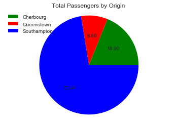

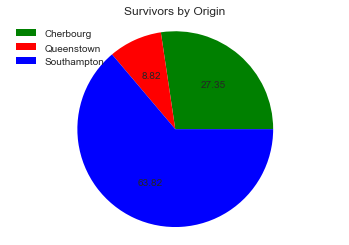

```python
group_names = ['Cherbourg','Queenstown','Southampton']

embarked_df = sample_data.groupby('Embarked').size()
embarked_df.plot(kind='pie', autopct='%.2f', labels=None, colors = ['g','r','b'])

plt.title('Total Passengers by Origin')
plt.axis('equal')
plt.ylabel('')
plt.legend(labels=group_names, loc="best")
plt.show()




embarked_survivors = survived_df.groupby('Embarked').size()
embarked_survivors.plot(kind='pie', autopct='%.2f', labels=None, colors = ['g','r','b'])
plt.title('Survivors by Origin')
plt.axis('equal')
plt.ylabel('')
plt.legend(labels=group_names, loc="best")
plt.show()
```

We can see that most passengers were from Southampton and that most survivors were from Southampton. Comparing the two pie graphs is a great visual but a better insight to survival rate would be a bar graph. Next I created a bar graph to a get a better grasp of the Embarked data.

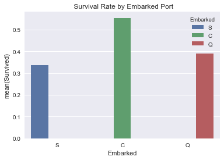

```python
sns.barplot(x="Embarked", y="Survived", hue="Embarked", data=sample_data, ci =None)
plt.title(" Survival Rate by Embarked Port")
```

Now with the survival rates plotted in a bar graph we can see the true nature of the survival rates. Although most survivors were from Southampton most perished, giving Southampton the worst survival rate. This leaves those who departed from Cherbourg with the best survival rate.

Next we will see if there is any underlying determinates that can answer why Cherbourg has the highest survival rate. Here I started by plotting pclass by embarked port.

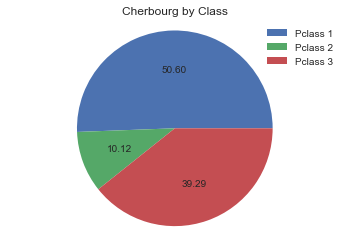

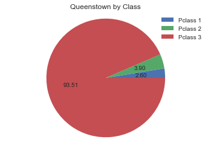

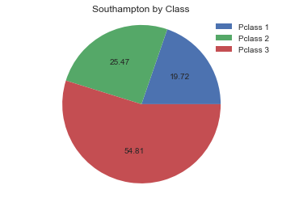

```python
cherbourg_df = (sample_data.loc[sample_data['Embarked'] == 'C'])


cherbourg_labels = ('Pclass 1', 'Pclass 2', 'Pclass 3')
cherbourg_pclass = cherbourg_df.groupby('Pclass').size()
cherbourg_pclass.plot(kind='pie', autopct='%.2f', labels=None)
plt.title('Cherbourg by Class')
plt.axis('equal')
plt.ylabel('')
plt.legend(labels=cherbourg_labels, loc="best")
plt.show()


queenstown_df = (sample_data.loc[sample_data['Embarked'] == 'Q'])


queenstown_labels = ('Pclass 1', 'Pclass 2', 'Pclass 3')
queenstown_pclass = queenstown_df.groupby('Pclass').size()
queenstown_pclass.plot(kind='pie', autopct='%.2f', labels=None)
plt.title('Queenstown by Class')
plt.axis('equal')
plt.ylabel('')
plt.legend(labels=queenstown_labels, loc="best")
plt.show()

southampton_df = (sample_data.loc[sample_data['Embarked'] == 'S'])


southampton_labels = ('Pclass 1', 'Pclass 2', 'Pclass 3')
southampton_pclass = southampton_df.groupby('Pclass').size()
southampton_pclass.plot(kind='pie', autopct='%.2f', labels=None)
plt.title('Southampton by Class')
plt.axis('equal')
plt.ylabel('')
plt.legend(labels=southampton_labels, loc="best")
plt.show()
```

After breaking down each port by Pclass we can see that which port you came from probably wasn't as important than which class you were in. Cherbourg has the highest amount of 1st class passengers and because 1st class passengers have such a high survival rate embarking from Cherbourg appears to have a high survival rate. However, Pclass is the underlying determinate and not the Embarked port.

## Conclusions

After studying the graphs above the strongest factors for survival on the Titanic start to materialize. The first factor in surviving would be which Pclass the passenger was in. THe survival rates was one of the highest at 64%. In fact after sutdying schematics of the Titanic first class passengers were placed higher up on the ship potentially gaining them easier access to life boats.

### Titanic Schematic (Photo Credits: Britannica.com)

[figure not shown]

```python
sns.barplot(x="Sex", y="Survived", hue="Pclass", data=sample_data, ci=None)
```

[output not shown]

Another big factor was the gender of the passenger. Overall, female passengers had a greater survivability than their male counterparts. However Pclass also had a significant impact of the female survival rate. And from the female only data display the distribution of ages I believe that Pclass had a greater factor than the age group.

[figure not shown]

```python
fig, axs = plt.subplots(1, 2, figsize=(16,8))

female_survived = female_df.groupby('Survived')
color=['b','g']
for ind, grp in female_survived:
    grp['Age'].plot(kind='hist', color=color[ind], ax = axs[ind])
axs[0].set_xlabel('Ages of Deceased Females')
axs[0].set_ylabel('Number of  Female Passengers')
axs[0].set_title('Histogram showing number of deceased females in each age group')

axs[1].set_xlabel('Ages of Survived Females')
axs[1].set_ylabel('Number of Female Passengers')
axs[1].set_title('Histogram showing number of deceased females in each age group')
```

##### A second look at the Age distribution for female only data (above)

### Limitations with the Data

One limitation with the data is that this is only a sample of the whole population. Certain parts of the data could be concentrated in this sample that is truly reflected in the total population. One possible example could be that our sample size captured a larger percentage female survivors than the actual population. An undersized sample could lead to false-positives or over estimate the magnitude of an association.

Another limitation is that we do not know the collection methods used to select this particular sample. Was it alphabetical? Random? Or using some sort of bias? This could be troublesome because certain collection methods may not give a suitable sample population ie there may be an underlying bias in the data.

### Final statement

If one were to expect the best survivabiity rate for any particular passenger the most important factors would be:

1. Pclass
2. Gender